# PISA Math Analysis Round 2

Robert

11/27/2014

We continue today with our analysis of the PISA student.

If you haven’t read from the start, follow this link.

We can update our model by using the `update` function.

```r
load("~/Github/pisa/student2012_NA.rda")
mathLM2 = update(object = mathLM1, formula. = . ~ . + CNT)
```

The `. ~ .` in the new formula means to use all the variables that were on the left hand and right hand side. The `+ CNT` adds the variable for Region. We can compare these nested models with a $\chi^2$ test.

```r
anova(mathLM1, mathLM2, test="Chisq")
```

```
## Analysis of Variance Table
##
## Model 1: PV1MATH ~ ST29Q01 + ST29Q03 + ST29Q04
## Model 2: PV1MATH ~ ST29Q01 + ST29Q03 + ST29Q04 + CNT
##   Res.Df       RSS Df Sum of Sq  Pr(>Chi)
## 1  42695 348108617
## 2  42690 269167187  5  78941431 < 2.2e-16 ***
## ---
## Signif. codes:  0 '***' 0.001 '**' 0.01 '*' 0.05 '.' 0.1 ' ' 1
```

The library `sjPlot` is a great resource for visualizing these models. The author’s [blog](http://strengejacke.wordpress.com/2013/03/22/plotting-lm-and-glm-models-with-ggplot-rstats/) has more details. Here’s an example of the `sjp.lm` function for plotting coefficients:

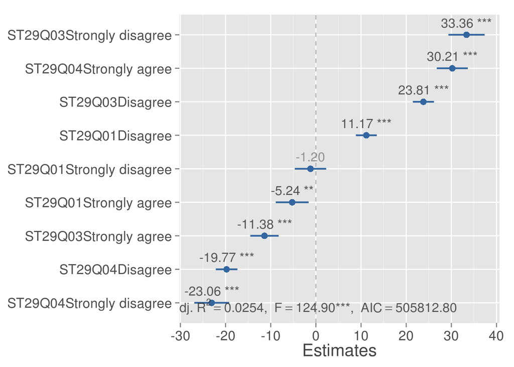

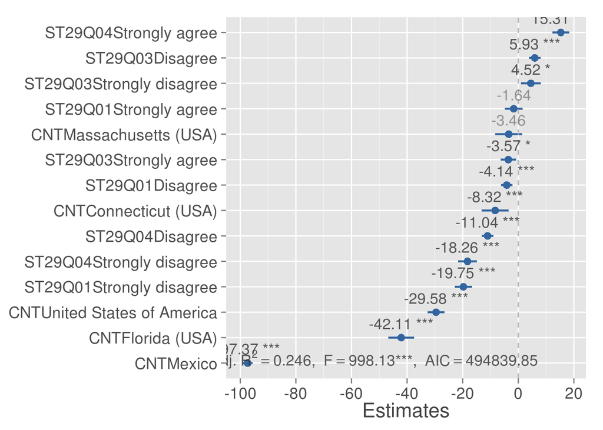

Another way to perform anova on nested models is by using `drop1` or `add1`.

```r
add1(mathLM2, scope = ~.^2, test="Chisq")
```

```
## Single term additions
##
## Model:
## PV1MATH ~ ST29Q01 + ST29Q03 + ST29Q04 + CNT
##                 Df Sum of Sq       RSS    AIC  Pr(>Chi)
## <none>                       269167187 373646
## ST29Q01:ST29Q03  9    557312 268609875 373576 3.235e-15 ***
## ST29Q01:ST29Q04  9    603980 268563207 373568 < 2.2e-16 ***
## ST29Q01:CNT     15   2059014 267108173 373348 < 2.2e-16 ***
## ST29Q03:ST29Q04  9    361970 268805216 373607 4.112e-09 ***
## ST29Q03:CNT     15    560783 268606403 373587 1.482e-12 ***
## ST29Q04:CNT     15   2513004 266654182 373276 < 2.2e-16 ***
## ---
## Signif. codes:  0 '***' 0.001 '**' 0.01 '*' 0.05 '.' 0.1 ' ' 1
```

```r
mathLM3 = update(mathLM2, direction = "both")
summary(mathLM3)
```

```
##
## Call:
## lm(formula = PV1MATH ~ ST29Q01 + ST29Q03 + ST29Q04 + CNT, data = student2012,
##     direction = "both")
##
## Residuals:
##     Min      1Q  Median      3Q     Max
## -315.51  -54.10   -1.48   53.40  318.74
##
## Coefficients:
##                             Estimate Std. Error  t value Pr(>|t|)
## (Intercept)                 522.7579     1.0231  510.940  < 2e-16 ***
## ST29Q01Disagree              -4.1413     1.0458   -3.960 7.50e-05 ***
## ST29Q01Strongly agree        -1.6364     1.6342   -1.001 0.316669
## ST29Q01Strongly disagree    -19.7524     1.5707  -12.576  < 2e-16 ***
## ST29Q03Disagree               5.9297     1.0625    5.581 2.41e-08 ***
## ST29Q03Strongly agree        -3.5706     1.4108   -2.531 0.011380 *
## ST29Q03Strongly disagree      4.5167     1.8210    2.480 0.013127 *
## ST29Q04Disagree             -11.0369     1.0788  -10.231  < 2e-16 ***
## ST29Q04Strongly agree        15.3096     1.5446    9.911  < 2e-16 ***
## ST29Q04Strongly disagree    -18.2619     1.7319  -10.544  < 2e-16 ***
## CNTConnecticut (USA)         -8.3152     2.4787   -3.355 0.000795 ***
## CNTFlorida (USA)            -42.1132     2.3714  -17.759  < 2e-16 ***
## CNTMassachusetts (USA)       -3.4561     2.4832   -1.392 0.163985
## CNTMexico                   -97.3719     0.9089 -107.136  < 2e-16 ***
## CNTUnited States of America -29.5845     1.5515  -19.068  < 2e-16 ***
## ---
## Signif. codes:  0 '***' 0.001 '**' 0.01 '*' 0.05 '.' 0.1 ' ' 1
##
## Residual standard error: 79.41 on 42690 degrees of freedom
##   (22939 observations deleted due to missingness)
## Multiple R-squared:  0.2466, Adjusted R-squared:  0.2464
## F-statistic: 998.1 on 14 and 42690 DF,  p-value: < 2.2e-16
```

It may be more practical to add in variables/interactions one at a time and see how the model changes. Many things have yet to be discovered in the PISA dataset. I am looking forward to finding out how attitudes towards math vary across different regions. It is apparent that geography plays an important role in determine mathematical aptitude, but should that be the case? More to come…